[figure not shown]

# PyFixest: Fast High-Dimensional Fixed Effects Regression in Python

[figure not shown]

`PyFixest` is a Python implementation of the formidable fixest package for fast high-dimensional fixed effects regression.

The package aims to mimic `fixest's` defaults as closely as Python allows: if you know `fixest` well, the goal is that you won’t have to read the docs to get started! In particular, this means that all of `fixest's` defaults are mirrored by `PyFixest`.

Nevertheless, for a quick introduction, you can take a look at the [documentation](https://py-econometrics.github.io/pyfixest/pyfixest.html) or the regression chapter of [Arthur Turrell’s](https://github.com/aeturrell) book on [Coding for Economists](https://aeturrell.github.io/coding-for-economists/econmt-regression.html#imports).

For questions on `PyFixest`, head on over to our [github discussions](https://github.com/py-econometrics/pyfixest/discussions), or (more informally) join our [Discord server](https://discord.gg/gBAydeDMVK).

## Support PyFixest

If you enjoy using `PyFixest`, please consider donating to [GiveDirectly](https://donate.givedirectly.org/dedicate) and dedicating your donation to `pyfixest.dev@gmail.com`. You can also leave a message through the donation form - your support and encouragement mean a lot to the developers!

## Features

- **OLS**, **WLS** and **IV** Regression with Fixed-Effects Demeaning via [Frisch-Waugh-Lovell](https://bookdown.org/ts_robinson1994/10EconometricTheorems/frisch.html)
- **Poisson Regression** following the [pplmhdfe algorithm](https://journals.sagepub.com/doi/full/10.1177/1536867X20909691)
- Probit, Logit and Gaussian Family **GLMs** (currently without fixed effects demeaning, this is WIP)
- **Quantile Regression** using an Interior Point Solver
- Multiple Estimation Syntax
- Several **Robust** and **Cluster Robust Variance-Covariance** Estimators
- **Wild Cluster Bootstrap** Inference (via wildboottest)
- **Difference-in-Differences** Estimators:
  - The canonical Two-Way Fixed Effects Estimator
  - [Gardner’s two-stage (“`Did2s`”)](https://jrgcmu.github.io/2sdd_current.pdf) estimator
  - Basic Versions of the Local Projections estimator following [Dube et al (2023)](https://www.nber.org/papers/w31184)
  - The fully saturated Event-Study estimator following [Sun & Abraham (2021)](https://www.sciencedirect.com/science/article/abs/pii/S030440762030378X)
- **Multiple Hypothesis Corrections** following the Procedure by [Romano and Wolf](https://journals.sagepub.com/doi/pdf/10.1177/1536867X20976314) and **Simultaneous Confidence Intervals** using a **Multiplier Bootstrap**
- Fast **Randomization Inference** as in the [ritest Stata package](https://hesss.org/ritest.pdf)
- The **Causal Cluster Variance Estimator (CCV)** following [Abadie et al.](https://economics.mit.edu/sites/default/files/2022-09/When%20Should%20You%20Adjust%20Standard%20Errors%20for%20Clustering.pdf)
- Regression **Decomposition** following [Gelbach (2016)](https://papers.ssrn.com/sol3/papers.cfm?abstract_id=1425737)
- **Publication-ready tables** with [Great Tables](https://posit-dev.github.io/great-tables/articles/intro.html) or LaTex booktabs

## Installation

You can install the release version from `PyPI` by running

```python
# inside an active virtual environment
python -m pip install pyfixest
```

or the development version from github by running

```python
python -m pip install git+https://github.com/py-econometrics/pyfixest
```

For visualization features using the lets-plot backend, install the optional dependency:

```python
python -m pip install pyfixest[plots]
```

Note that matplotlib is included by default, so you can always use the matplotlib backend for plotting even without installing the optional lets-plot dependency.

## Benchmarks

All benchmarks follow the [fixest benchmarks](https://github.com/lrberge/fixest/tree/master/_BENCHMARK). All non-pyfixest timings are taken from the `fixest` benchmarks.

[figure not shown]

## Quickstart

```python
import pyfixest as pf

data = pf.get_data()
pf.feols("Y ~ X1 | f1 + f2", data=data).summary()
```

```
###

Estimation:  OLS
Dep. var.: Y, Fixed effects: f1+f2
Inference:  CRV1
Observations:  997

| Coefficient   |   Estimate |   Std. Error |   t value |   Pr(>|t|) |   2.5% |   97.5% |
|:--------------|-----------:|-------------:|----------:|-----------:|-------:|--------:|
| X1            |     -0.919 |        0.065 |   -14.057 |      0.000 | -1.053 |  -0.786 |
---
RMSE: 1.441   R2: 0.609   R2 Within: 0.2
```

### Multiple Estimation

You can estimate multiple models at once by using [multiple estimation syntax](https://aeturrell.github.io/coding-for-economists/econmt-regression.html#multiple-regression-models):

```python
# OLS Estimation: estimate multiple models at once
fit = pf.feols("Y + Y2 ~X1 | csw0(f1, f2)", data = data, vcov = {'CRV1':'group_id'})
# Print the results
fit.etable()
```

```
                           est1               est2               est3               est4               est5               est6
------------  -----------------  -----------------  -----------------  -----------------  -----------------  -----------------
depvar                        Y                 Y2                  Y                 Y2                  Y                 Y2
------------------------------------------------------------------------------------------------------------------------------
Intercept      0.919*** (0.121)   1.064*** (0.232)
X1            -1.000*** (0.117)  -1.322*** (0.211)  -0.949*** (0.087)  -1.266*** (0.212)  -0.919*** (0.069)  -1.228*** (0.194)
------------------------------------------------------------------------------------------------------------------------------
f2                            -                  -                  -                  -                  x                  x
f1                            -                  -                  x                  x                  x                  x
------------------------------------------------------------------------------------------------------------------------------
R2                        0.123              0.037              0.437              0.115              0.609              0.168
S.E. type          by: group_id       by: group_id       by: group_id       by: group_id       by: group_id       by: group_id
Observations                998                999                997                998                997                998
------------------------------------------------------------------------------------------------------------------------------
Significance levels: * p < 0.05, ** p < 0.01, *** p < 0.001
Format of coefficient cell:
Coefficient (Std. Error)
```

### Adjust Standard Errors “on-the-fly”

Standard Errors can be adjusted after estimation, “on-the-fly”:

```python
fit1 = fit.fetch_model(0)
fit1.vcov("hetero").summary()
```

```
Model:  Y~X1
###

Estimation:  OLS
Dep. var.: Y
Inference:  hetero
Observations:  998

| Coefficient   |   Estimate |   Std. Error |   t value |   Pr(>|t|) |   2.5% |   97.5% |
|:--------------|-----------:|-------------:|----------:|-----------:|-------:|--------:|
| Intercept     |      0.919 |        0.112 |     8.223 |      0.000 |  0.699 |   1.138 |
| X1            |     -1.000 |        0.082 |   -12.134 |      0.000 | -1.162 |  -0.838 |
---
RMSE: 2.158   R2: 0.123
```

### Poisson Regression via `fepois()`

You can estimate Poisson Regressions via the `fepois()` function:

```python
poisson_data = pf.get_data(model = "Fepois")
pf.fepois("Y ~ X1 + X2 | f1 + f2", data = poisson_data).summary()
```

```
###

Estimation:  Poisson
Dep. var.: Y, Fixed effects: f1+f2
Inference:  CRV1
Observations:  997

| Coefficient   |   Estimate |   Std. Error |   t value |   Pr(>|t|) |   2.5% |   97.5% |
|:--------------|-----------:|-------------:|----------:|-----------:|-------:|--------:|
| X1            |     -0.007 |        0.035 |    -0.190 |      0.850 | -0.075 |   0.062 |
| X2            |     -0.015 |        0.010 |    -1.449 |      0.147 | -0.035 |   0.005 |
---
Deviance: 1068.169
```

### IV Estimation via three-part formulas

Last, `PyFixest` also supports IV estimation via three part formula syntax:

```python
fit_iv = pf.feols("Y ~ 1 | f1 | X1 ~ Z1", data = data)
fit_iv.summary()
```

```
###

Estimation:  IV
Dep. var.: Y, Fixed effects: f1
Inference:  CRV1
Observations:  997

| Coefficient   |   Estimate |   Std. Error |   t value |   Pr(>|t|) |   2.5% |   97.5% |
|:--------------|-----------:|-------------:|----------:|-----------:|-------:|--------:|
| X1            |     -1.025 |        0.115 |    -8.930 |      0.000 | -1.259 |  -0.790 |
---
```

## Call for Contributions

Thanks for showing interest in contributing to `pyfixest`! We appreciate all contributions and constructive feedback, whether that be reporting bugs, requesting new features, or suggesting improvements to documentation.

If you’d like to get involved, but are not yet sure how, please feel free to send us an email. Some familiarity with either Python or econometrics will help, but you really don’t need to be a `numpy` core developer or have published in [Econometrica](https://onlinelibrary.wiley.com/journal/14680262) =) We’d be more than happy to invest time to help you get started!

## Contributors ✨

Thanks goes to these wonderful people:

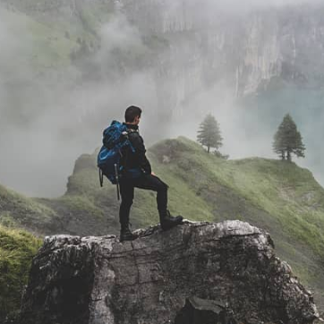

<sub>**styfenschaer**</sub>  
[💻](https://github.com/py-econometrics/pyfixest/commits?author=styfenschaer)

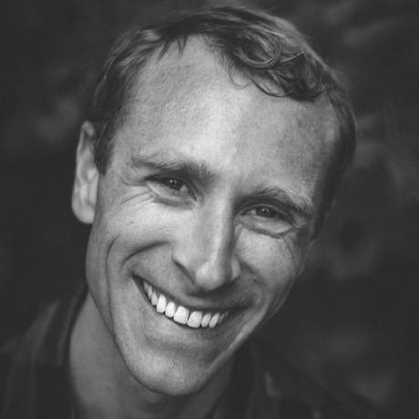

<sub>**Niall Keleher**</sub>  
🚇 [💻](https://github.com/py-econometrics/pyfixest/commits?author=NKeleher)

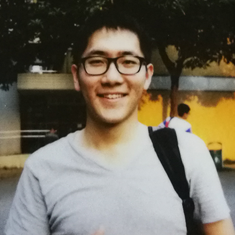

<sub>**Wenzhi Ding**</sub>  
[💻](https://github.com/py-econometrics/pyfixest/commits?author=Wenzhi-Ding)

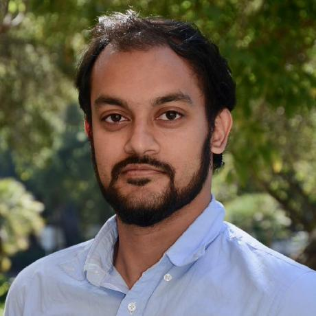

<sub>**Apoorva Lal**</sub>  
[💻](https://github.com/py-econometrics/pyfixest/commits?author=apoorvalal) [🐛](https://github.com/py-econometrics/pyfixest/issues?q=author%3Aapoorvalal)

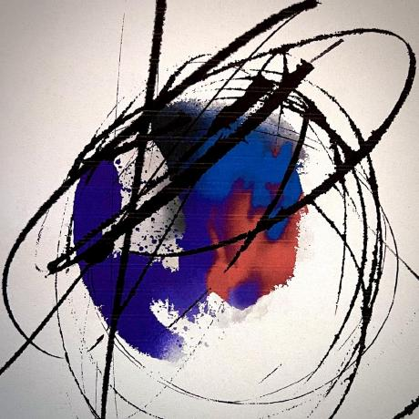

<sub>**Juan Orduz**</sub>  
🚇 [💻](https://github.com/py-econometrics/pyfixest/commits?author=juanitorduz)

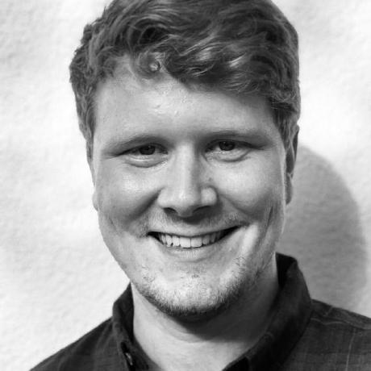

<sub>**Alexander Fischer**</sub>  
[💻](https://github.com/py-econometrics/pyfixest/commits?author=s3alfisc) 🚇

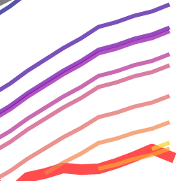

<sub>**aeturrell**</sub>  
✅ [📖](https://github.com/py-econometrics/pyfixest/commits?author=aeturrell) 📣

[figure not shown]

<sub>**leostimpfle**</sub>  
[💻](https://github.com/py-econometrics/pyfixest/commits?author=leostimpfle) [🐛](https://github.com/py-econometrics/pyfixest/issues?q=author%3Aleostimpfle)

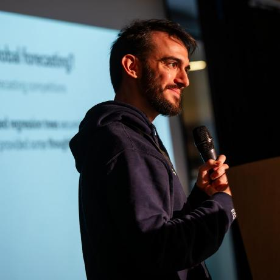

<sub>**baggiponte**</sub>  
[📖](https://github.com/py-econometrics/pyfixest/commits?author=baggiponte)

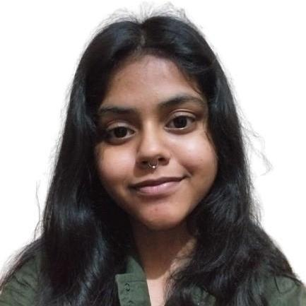

<sub>**Sanskriti**</sub>  
🚇

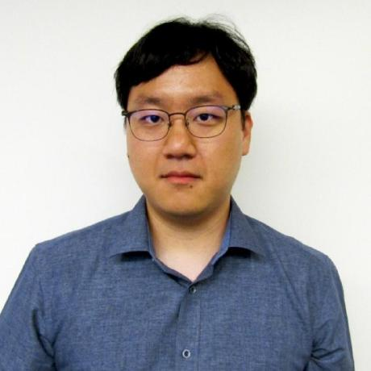

<sub>**Jaehyung**</sub>  
[💻](https://github.com/py-econometrics/pyfixest/commits?author=Jayhyung)

[figure not shown]

<sub>**Alex**</sub>  
[📖](https://github.com/py-econometrics/pyfixest/commits?author=asteves)

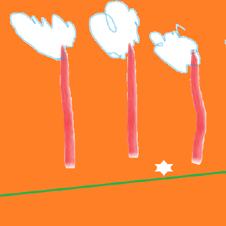

<sub>**Hayden Freedman**</sub>  
[💻](https://github.com/py-econometrics/pyfixest/commits?author=greenguy33) [📖](https://github.com/py-econometrics/pyfixest/commits?author=greenguy33)

[figure not shown]

<sub>**Aziz Mamatov**</sub>  
[💻](https://github.com/py-econometrics/pyfixest/commits?author=saidamir)

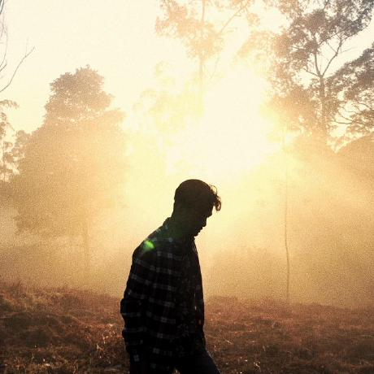

<sub>**rafimikail**</sub>  
[💻](https://github.com/py-econometrics/pyfixest/commits?author=rafimikail)

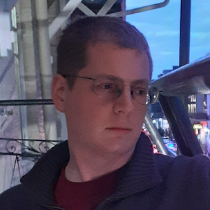

<sub>**Benjamin Knight**</sub>  
[💻](https://github.com/py-econometrics/pyfixest/commits?author=b-knight)

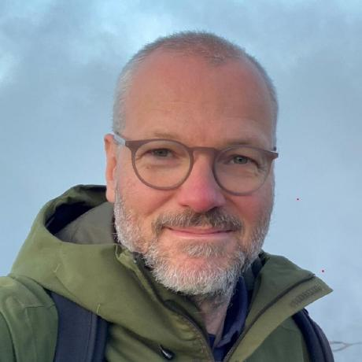

<sub>**Dirk Sliwka**</sub>  
[💻](https://github.com/py-econometrics/pyfixest/commits?author=dsliwka) [📖](https://github.com/py-econometrics/pyfixest/commits?author=dsliwka)

[figure not shown]

<sub>**daltonm-bls**</sub>  
[🐛](https://github.com/py-econometrics/pyfixest/issues?q=author%3Adaltonm-bls)

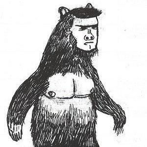

<sub>**Marc-André**</sub>  
[💻](https://github.com/py-econometrics/pyfixest/commits?author=marcandre259) [🐛](https://github.com/py-econometrics/pyfixest/issues?q=author%3Amarcandre259)

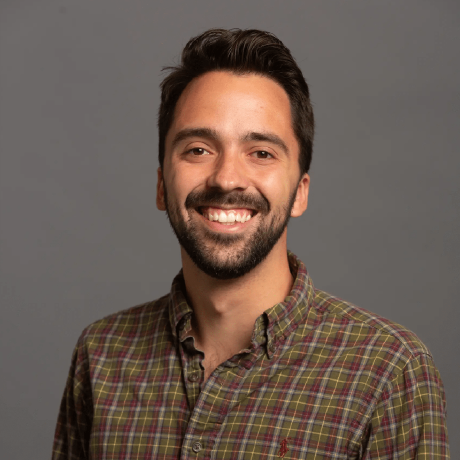

<sub>**Kyle F Butts**</sub>  
🔣

[figure not shown]

<sub>**Marco Edward Gorelli**</sub>  
[👀](https://github.com/py-econometrics/pyfixest/pulls?q=is%3Apr+reviewed-by%3AMarcoGorelli)

[figure not shown]

<sub>**Vincent Arel-Bundock**</sub>  
[💻](https://github.com/py-econometrics/pyfixest/commits?author=vincentarelbundock)

[figure not shown]

<sub>**IshwaraHegde97**</sub>  
[💻](https://github.com/py-econometrics/pyfixest/commits?author=IshwaraHegde97)

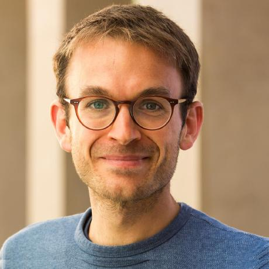

<sub>**Tobias Schmidt**</sub>  
[📖](https://github.com/py-econometrics/pyfixest/commits?author=RoyalTS)

[figure not shown]

<sub>**escherpf**</sub>  
[🐛](https://github.com/py-econometrics/pyfixest/issues?q=author%3Aescherpf) [💻](https://github.com/py-econometrics/pyfixest/commits?author=escherpf)

[figure not shown]

<sub>**Iván Higuera Mendieta**</sub>  
[💻](https://github.com/py-econometrics/pyfixest/commits?author=ivanhigueram)

[figure not shown]

<sub>**Ádám Vig**</sub>  
[💻](https://github.com/py-econometrics/pyfixest/commits?author=adamvig96)

[figure not shown]

<sub>**Szymon Sacher**</sub>  
[💻](https://github.com/py-econometrics/pyfixest/commits?author=elchorro)